# Assignment_2.1_BreitbachScott

Scott Breitbach

6/11/2020

## 2.1 Assignment: 2014 American Community Survey

### 1. What are the elements in your data (including the categories and data types)?

```r
class(acs2014$Id)
```

```
## [1] "character"
```

```r
class(acs2014$Id2)
```

```
## [1] "integer"
```

```r
class(acs2014$Geography)
```

```
## [1] "character"
```

```r
class(acs2014$PopGroupID)
```

```
## [1] "integer"
```

```r
class(acs2014$POPGROUP.display.label)
```

```
## [1] "character"
```

```r
class(acs2014$RacesReported)
```

```
## [1] "integer"
```

```r
class(acs2014$HSDegree)
```

```
## [1] "numeric"
```

```r
typeof(acs2014$HSDegree)
```

```
## [1] "double"
```

```r
class(acs2014$BachDegree)
```

```
## [1] "numeric"
```

```r
typeof(acs2014$BachDegree)
```

```
## [1] "double"
```

### 2. Please provide the output from the following functions: str(); nrow(); ncol()

```r
str(acs2014)
```

```
## 'data.frame':    136 obs. of  8 variables:
##  $ Id                    : chr  "0500000US01073" "0500000US04013" "0500000US04019" "0500000US06001" ...
##  $ Id2                   : int  1073 4013 4019 6001 6013 6019 6029 6037 6059 6065 ...
##  $ Geography             : chr  "Jefferson County, Alabama" "Maricopa County, Arizona" "Pima County, Arizona" "Alameda County, California" ...
##  $ PopGroupID            : int  1 1 1 1 1 1 1 1 1 1 ...
##  $ POPGROUP.display.label: chr  "Total population" "Total population" "Total population" "Total population" ...
##  $ RacesReported         : int  660793 4087191 1004516 1610921 1111339 965974 874589 10116705 3145515 2329271 ...
##  $ HSDegree              : num  89.1 86.8 88 86.9 88.8 73.6 74.5 77.5 84.6 80.6 ...
##  $ BachDegree            : num  30.5 30.2 30.8 42.8 39.7 19.7 15.4 30.3 38 20.7 ...
```

```r
nrow(acs2014)
```

```
## [1] 136
```

```r
ncol(acs2014)
```

```
## [1] 8
```

### 3. Create a Histogram of the HSDegree variable using the ggplot2 package.

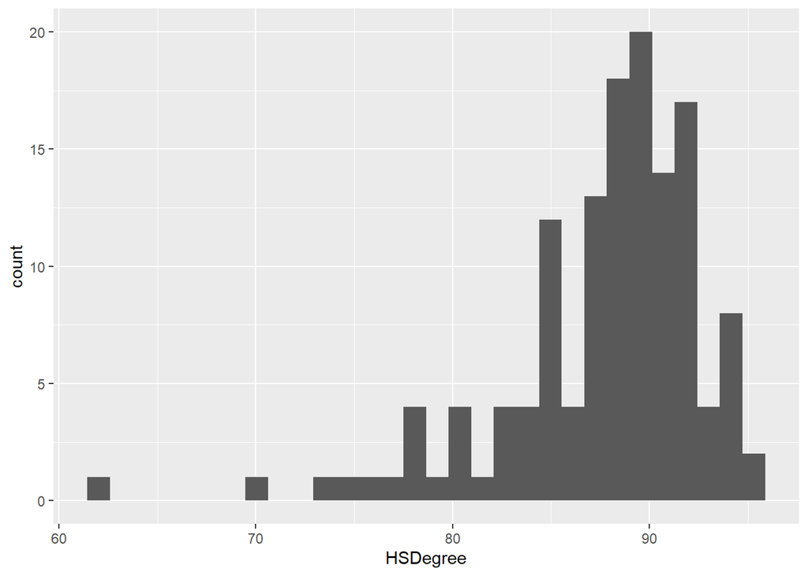

```r
acs14Histogram <- ggplot(acs2014, aes(HSDegree))
acs14Histogram + geom_histogram()
```

#### a. Set a bin size for the Histogram.

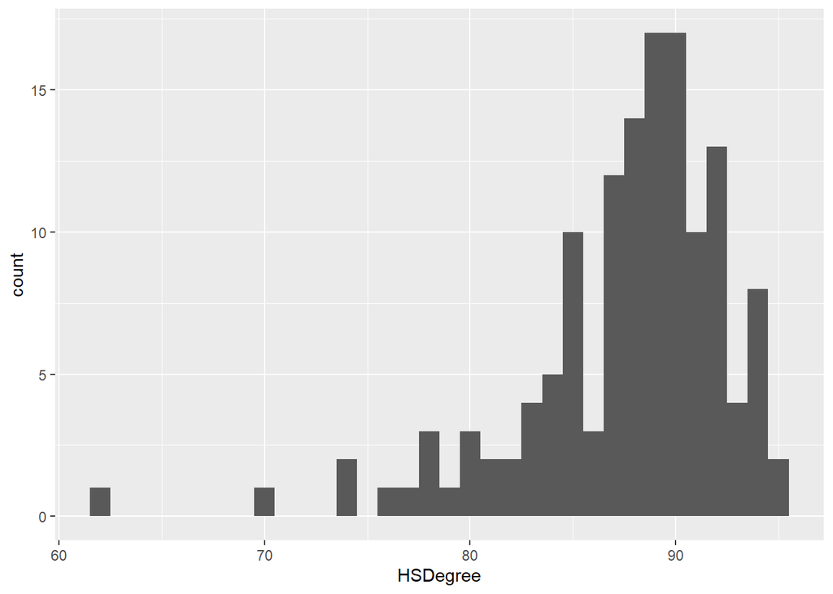

```r
acs14Histogram + geom_histogram(binwidth = 1)
```

```r
acs14Histogram <- acs14Histogram + geom_histogram(binwidth = 1)
```

#### b. Include a Title and appropriate X/Y axis labels on your Histogram Plot.

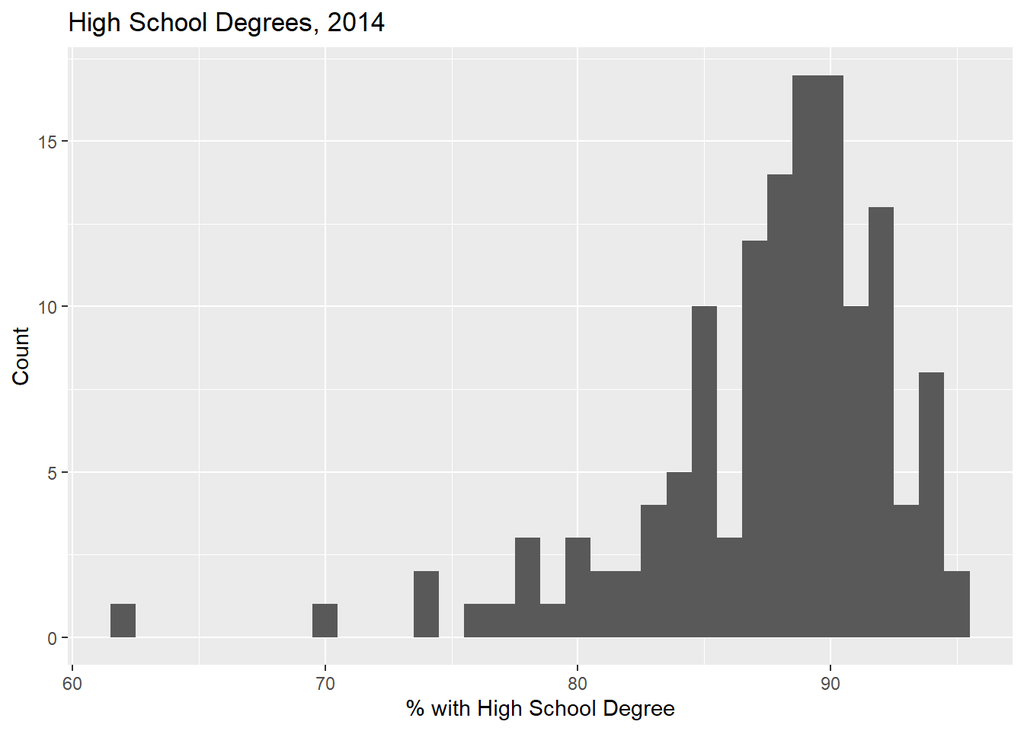

```r
acs14Histogram + labs(x = "% with High School Degree", y = "Count",
                      title = "High School Degrees, 2014")
```

```r
acs14Histogram <- acs14Histogram +
  labs(x = "% with High School Degree", y = "Count",
       title = "High School Degrees, 2014")
```

### 4. Answer the following questions based on the Histogram produced:

#### a. Based on what you see in this histogram, is the data distribution unimodal?

> The data distribution appears to be unimodal, somewhere around 89-90%.

#### b. Is it approximately symmetrical?

> The data appears to be negatively skewed, not symmetrical.

#### c. Is it approximately bell-shaped?

> Though skewed, the data does appear approximately bell-shaped.

#### e. If not normal, is the distribution skewed? If so, in which direction?

> The data is clustered toward the higher end and so is negatively skewed.

#### f. Include a normal curve to the Histogram that you plotted.

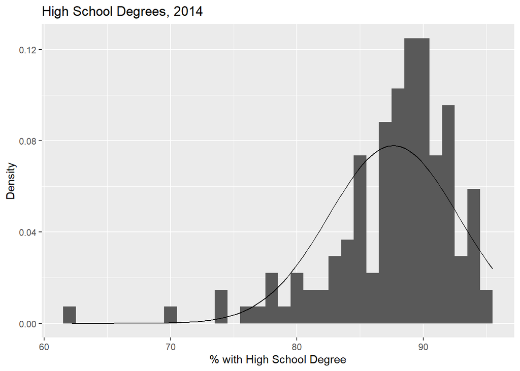

```r
acs14Density <- ggplot(acs2014, aes(HSDegree)) +
  geom_histogram(aes(y = ..density..), binwidth = 1) +
  labs(x = "% with High School Degree", y = "Density",
       title = "High School Degrees, 2014") +
  stat_function(fun = dnorm, args = list(mean = mean(acs2014$HSDegree),
                                         sd(acs2014$HSDegree)))
acs14Density
```

#### g. Explain whether a normal distribution can accurately be used as a model for this data.

> The normal curve does not appear to fit the data very well; it appears non-symmetrical and to be negatively skewed. Additionally, it appears not to fit the normal curve very well as the data is too pointy (positive kurtosis).

### 5. Create a Probability Plot of the HSDegree variable.

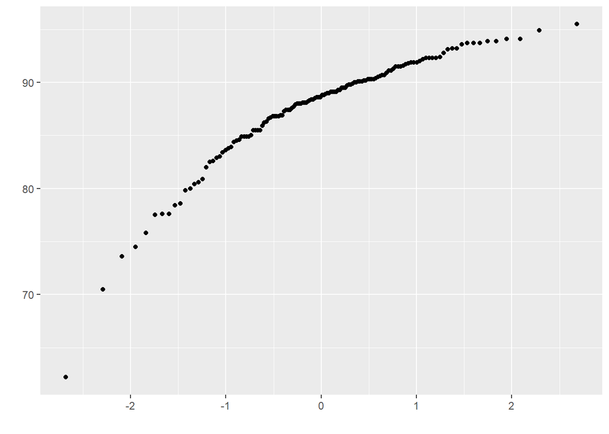

```r
qq.acs14.HSDegree <- qplot(sample = acs2014$HSDegree)
qq.acs14.HSDegree
```

### 6. Answer the following questions based on the Probability Plot:

#### a. Based on what you see in this probability plot, is the distribution approximately normal? Explain how you know.

> This distribution does not appear normal. If the data matched a normal distribution, we would expect the points to form a straght line. Devations from this line indicate deviations from normality.

#### b. If not normal, is the distribution skewed? If so, in which direction? Explain how you know.

> The data deviates from normal creating an upward curve, which indicates the data is clustered toward the high end of the scale, or negatively skewed.

### 7. Now that you have looked at this data visually for normality, you will now quantify normality with numbers using the stat.desc() function. Include a screen capture of the results produced.

```r
round(stat.desc(acs2014$HSDegree, basic = FALSE, norm = TRUE), digits = 3)
```

```
##       median         mean      SE.mean CI.mean.0.95          var      std.dev
##       88.700       87.632        0.439        0.868       26.193        5.118
##     coef.var     skewness     skew.2SE     kurtosis     kurt.2SE   normtest.W
##        0.058       -1.675       -4.030        4.353        5.274        0.877
##   normtest.p
##        0.000
```

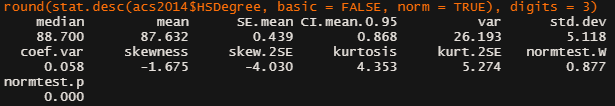

screen capture